# Normal (Gaussian) Distribution: The Math

October 20, 2021 @ 12:26 PM

## Before We Begin…

These slides are not meant to be standalone information. You should take notes to flesh out the contents. I recommend that you create an R Markdown document where you can combine information and code from the slides and your own additional notes and explorations to make connections.

**Related Materials**

- Ch 2 of *Mathematical Statistics with Resampling and R, 2<sup>nd</sup> Ed.*
- [Appendix A](https://moderndive.com/A-appendixA.html) of *Modern Dive*
- DataCamp [Foundations of Probability in R](https://www.datacamp.com/courses/foundations-of-probability-in-r)
- [Normal (Gaussian) Distribution: `R` Code](https://stat-jet-asu.github.io/StatisticalDataAnalysis1/Slides/NormalDistributionTheory.html) (slides)
- [Normal (Gaussian) Distribution: Assessing](https://stat-jet-asu.github.io/StatisticalDataAnalysis1/Slides/NormalAssessment.html) (slides)

## Notation and Parameters

The normal distribution is a continuous probability distribution. Very few concepts in real life are truly normally distributed, but many are *approximately* normal. The normal is also the limiting distribution for many common statistics and other distributions like the binomial when \(n \rightarrow \infty\).

\[X \sim N(\mu,\sigma^2)\]

\(x\) = {-\(\infty\) to +\(\infty\)} = *the sample space*

\(\mu\) = the mean (expected value) of the distribution

\(\sigma^2\) = the variance of the distribution

The **standard normal** distribution \(Z\) has \(\mu\) = 0 and \(\sigma^2\) = \(\sigma\) = 1.

## Probability Density Function (pdf)

Unlike the pmfs in discrete distributions, the probability density function (pdf) of a continuous distribution does not compute a probability, because the area under a point is zero. Instead, the pdf gives the height of the function (y) at x. Below is the pdf of the normal distribution.

\[f(x)=\frac{1}{\sqrt{2\pi}\sigma}e^{-(x-\mu)^2/(2\sigma^2)}\]

The shape will always be a bell. The critical parameters \(\mu\) and \(\sigma\) determine the location and the height/width of the curve. The mean can be any real number and the standard deviation can be any positive real number.

The area beneath a normal distribution curve is always 1.

## Visualizing the Standard Normal

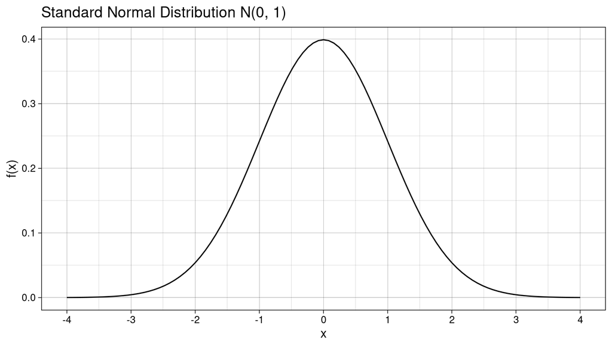

Notice that there is very little area under the curve outside ± \(3\).

## Another Normal Distribution

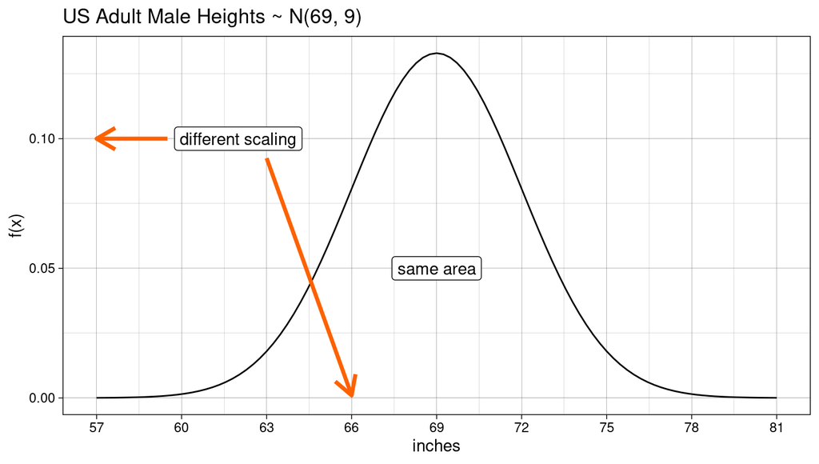

Notice that there is very little area under the curve outside ± \(3\sigma\).

## The Empirical Rule

The normal distribution is unimodal and perfectly symmetric.

[figure not shown]

- approximately 68% of the curve’s area is between \(\mu \pm 1\sigma\)
- approximately 95% of the curve’s area is between \(\mu \pm 2\sigma\)
- approximately 99.7% of the curve’s area is between \(\mu \pm 3\sigma\)

The tails extend to \(\pm \infty\) ; any value of \(x\) is *theoretically* possible.

## Cumulative Distribution Function (CDF)

The probability of the random variable \(X\) taking on a value less than or equal to a specific value \(x\) is found using the CDF, which integrates the area under the curve. This is similar to summing a discrete distribution like the binomial or calculating an empirical cumulative distribution function for a sample of data.

\[F(x)=P(X \leq x) = \int\limits_{-\infty}^{x} \frac{1}{\sqrt{2\pi}\sigma}e^{-(x-\mu)^2/(2\sigma^2)}dx\]

The normal distribution has no closed-form solution for \(F(x)\). `R` has a function for the normal CDF (and its inverse, which we will discuss later). Prior to digital technology, people used [tables of solutions](http://www.z-table.com/) computed for the standard normal curve Z.

## Visualizing the Standard Normal

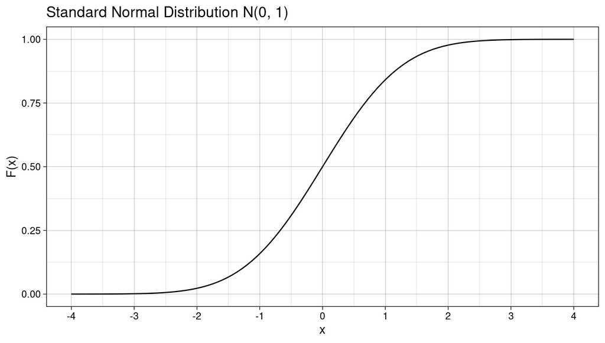

Notice the logistic (S) shape with the inflection point at \(\mu = 0\).

## Another Normal Distribution

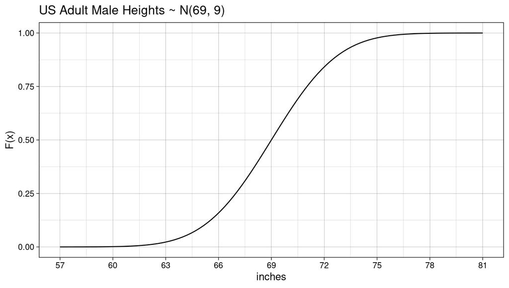

Notice the logistic (S) shape with the inflection point at \(\mu = 69\).

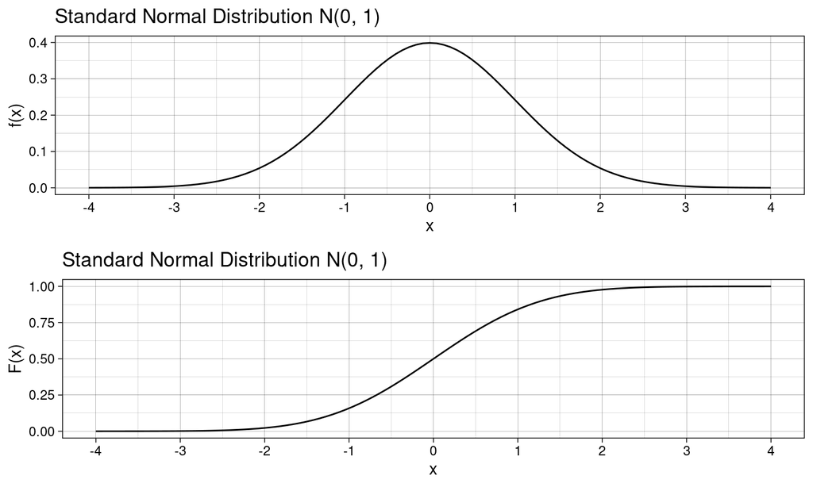

Notice how the two normal distribution plots correspond. Recall that \(F(x)\)—the CDF—is the integral of \(f(x)\)—the pdf.

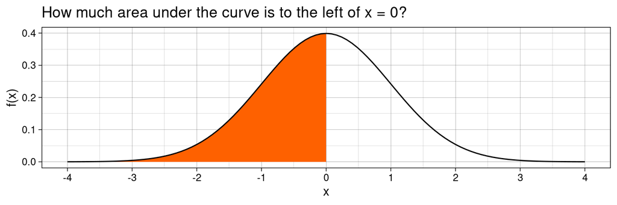

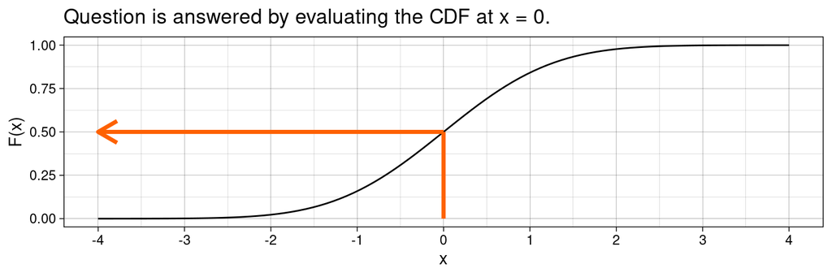

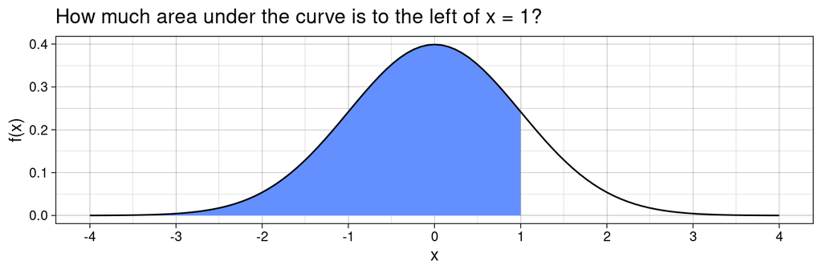

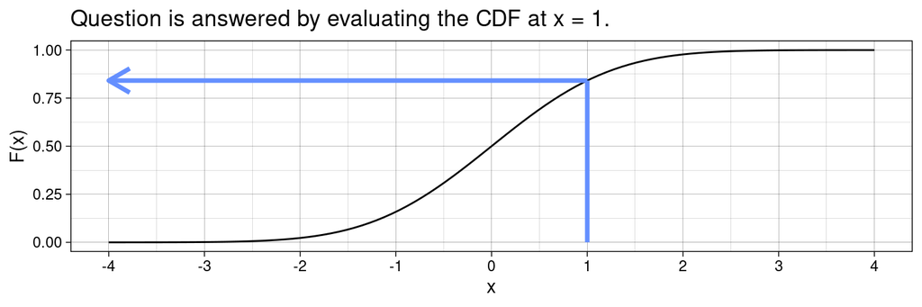

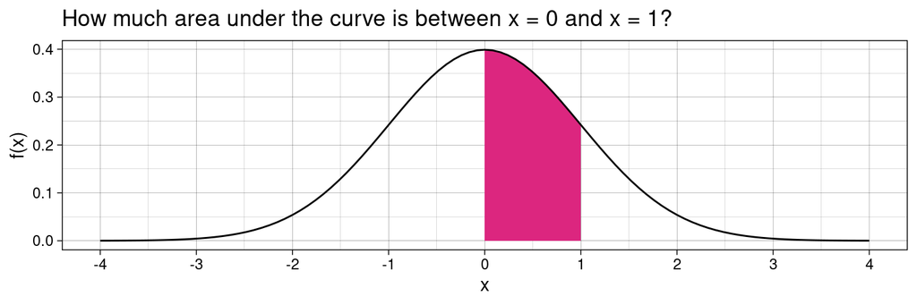

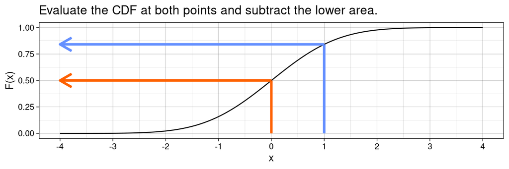

In other words, solving is the equivalent of integrating between 0 and 1 using the standard normal CDF with \(\mu = 0\) and \(\sigma = 1\).

\[\int\limits_{0}^{1} \frac{1}{\sqrt{2\pi}\sigma}e^{-(x-\mu)^2/(2\sigma^2)}dx\]

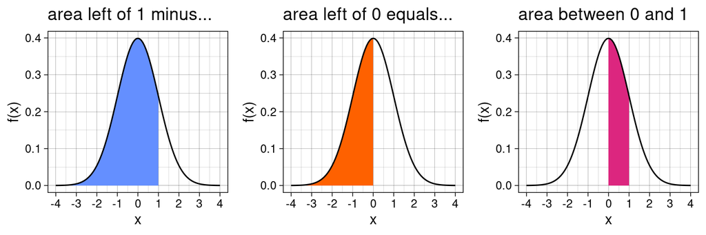

## Finding the Quantiles

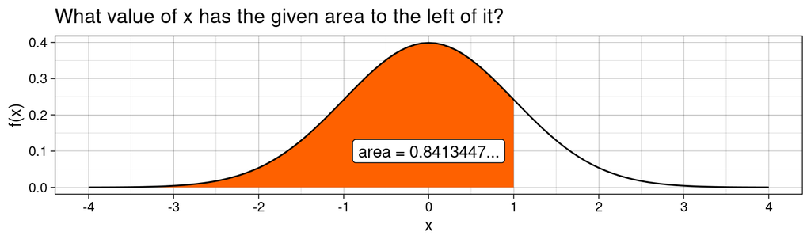

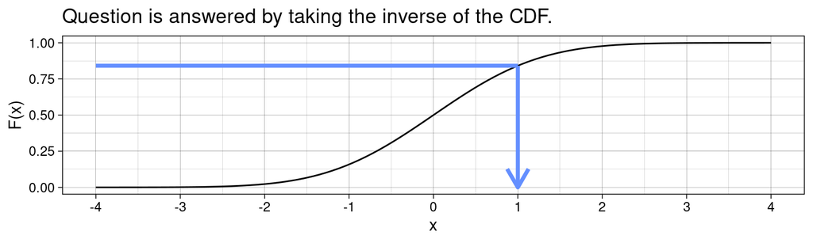

## More on Quantiles

The quantiles are the cumulative percentages and percentiles labeled on the image below. Note the cumulative percentages associated with the Empirical rule (\(1\sigma\), \(2\sigma\), and \(3\sigma\) above and below \(\mu\)). These are true for all normal distributions.

[figure not shown]

## But what about P(X = x)?

The normal distribution is a continuous function, so the area under a point is zero and \(P(X = x)\) is technically zero. Then how can we use the normal model for data?

Many variables are theoretically continuous, but measurements are always inherently discrete—we round all our measurements to some number of decimal places.

We treat \(P(X = x)\) as a narrow area beneath the curve rather than a single point. For example, if I measure people’s height in inches and round to two decimal places, the probability that a person is 70.00 inches tall (5’10") is modeled as the probability that they are between 69.995 and 70.005 inches.

## Expected Value and Variance

The theoretical expected value and variance for any distribution are generally found as follows. We cannot integrate \(f(x)\), but it can be demonstrated that expected value and variance simplify to the parameters \(\mu\) and \(\sigma^2\) for the normal distribution.

\[E[X] = \int\limits_{-\infty}^{+\infty} x f(x) \rightarrow \mu\]

\[Var[X] = \int\limits_{-\infty}^{+\infty} (x - \mu)^2 f(x) \rightarrow \sigma^2\]